## Tarea 2

Programa Experto en Inteligencia Artificial con Python  
ML3000 - Modelos Analíticos Avanzados  
Estudiante: Natalia Bonilla Villalobos.  
**Regresión Lineal Simple y Multiple**

# Menú

- Ejercicio 1
- Ejercicio 2
- Ejercicio 3

```python
import math
import statistics
import numpy as np
import pandas as pd
import seaborn as sns
import matplotlib.pyplot as plt

from sklearn.preprocessing import StandardScaler
from sklearn.model_selection import train_test_split

from sklearn.pipeline import Pipeline
from sklearn.compose import ColumnTransformer
from sklearn.preprocessing import OneHotEncoder, StandardScaler

# Linear Regression -> Regresión Lineal/Multiple
from sklearn.linear_model import LinearRegression
# Lasso Regression -> Regresión Lasso
from sklearn.linear_model import Lasso
from sklearn.linear_model import LassoCV
# Ridge Regression -> Regresión Ridge
from sklearn.linear_model import Ridge
from sklearn.linear_model import RidgeCV
# Support Vector Machine -> Máquinas de Soporte Vectorial
from sklearn.svm import SVR
# Decision Tree Regressor -> Árboles de Regresión
from sklearn.tree import DecisionTreeRegressor
# Random Forest Regressor -> Bosques Aleatorios
from sklearn.ensemble import RandomForestRegressor
# Gradient Boosting Regressor -> Potenciación
from sklearn.ensemble import GradientBoostingRegressor
# mostrar métricas para evaluar modelos
from sklearn.metrics import mean_squared_error, r2_score, mean_absolute_error
```

# Ejercicio 1

[50 puntos] En este ejercicio vamos a trabajar con los datos `seguro_v1.csv`, es un conjunto de datos de usuarios que han necesitado aplicar su seguro médico, donde se presentan distintas propiedades de cada individuo y el correspondiente costo del seguro médico. El objetivo es poder determinar o **predecir el costo del seguro médico**. El conjunto de datos tiene 1338 filas y 7 columnas, las cuales se explican a continuación.

Las variables de la tabla de datos son las siguientes:

- `edad`: Edad del beneficiario principal.
- `sexo`: Género del asegurado, femenino, masculino.
- `imc`: índice de masa corporal (IMC), que permite comprender el peso corporal, ya sea alto o bajo en relación con la estatura. índice objetivo de peso corporal (kg/m²) utilizando la relación entre la estatura y el peso, idealmente entre 18,5 y 24,9.
- `hijos`: Número de hijos cubiertos por el seguro médico / Número de dependientes.
- `fumador`: Fumador
- `region`: Zona residencial del beneficiario en EE. UU.: noreste, sureste, suroeste y noroeste.
- `costos`: Costos médicos individuales facturados por el seguro médico (variable a predecir).

Realice lo siguiente:

- a) Cargue la tabla de datos `seguro_v1.csv`, verifique su correcta lectura y elimine las filas con valores faltantes si los hubiera.
- b) Genere todos los métodos de regresión en Python vistos en clase para generar modelos de regresión usando el 85% de los datos para la tabla aprendizaje y un 15% para la tabla testing.
- c) Construya un DataFrame que compare los modelos generados en elítem anterior. Para esto en cada una de las filas debe aparecer un modelo predictivo y en las columnas aparezcan los índices Raíz del error cuadrático medio, Error relativo y Error absoluto medio e interprete los resultados.

Cuál de los modelos es mejor para estos datos y por qué?, recuerde que debe comparar contra el resumen numérico de la variable a predecir.

↑ Volver al Menú

## Parte 1

- a) Cargue la tabla de datos `seguro_v1.csv`, verifique su correcta lectura y elimine las filas con valores faltantes si los hubiera.

```python
df = pd.read_csv("data/seguro_v1.csv")
df.head(5)
```

|  | edad | sexo | imc | hijos | fumador | region | costos |
| --- | --- | --- | --- | --- | --- | --- | --- |
| 0 | 19 | femenino | 27.900 | 0 | si | suroeste | 16884.92400 |
| 1 | 18 | masculino | 33.770 | 1 | no | sureste | 1725.55230 |
| 2 | 28 | masculino | 33.000 | 3 | no | sureste | 4449.46200 |
| 3 | 33 | masculino | 22.705 | 0 | no | noroeste | 21984.47061 |
| 4 | 32 | masculino | 28.880 | 0 | no | noroeste | 3866.85520 |

```python
df.info()
```

```
<class 'pandas.core.frame.DataFrame'>
RangeIndex: 1338 entries, 0 to 1337
Data columns (total 7 columns):
 #   Column   Non-Null Count  Dtype
---  ------   --------------  -----
 0   edad     1338 non-null   int64
 1   sexo     1338 non-null   object
 2   imc      1338 non-null   float64
 3   hijos    1338 non-null   int64
 4   fumador  1338 non-null   object
 5   region   1338 non-null   object
 6   costos   1338 non-null   float64
dtypes: float64(2), int64(2), object(3)
memory usage: 73.3+ KB
```

```python
df.isnull().sum()
```

```
edad       0
sexo       0
imc        0
hijos      0
fumador    0
region     0
costos     0
dtype: int64
```

```python
df['region'] = df['region'].astype('category')
df['sexo'] = df['sexo'].astype('category')
df['fumador'] = df['fumador'].astype('category')
df.info()
```

```
<class 'pandas.core.frame.DataFrame'>
RangeIndex: 1338 entries, 0 to 1337
Data columns (total 7 columns):
 #   Column   Non-Null Count  Dtype
---  ------   --------------  -----
 0   edad     1338 non-null   int64
 1   sexo     1338 non-null   category
 2   imc      1338 non-null   float64
 3   hijos    1338 non-null   int64
 4   fumador  1338 non-null   category
 5   region   1338 non-null   category
 6   costos   1338 non-null   float64
dtypes: category(3), float64(2), int64(2)
memory usage: 46.3 KB
```

**Distribución de Variable a Predecir**

```python
def distVariableToBePredicted(predVar):
    moda = predVar.mode()[0]
    suma = predVar.sum()
    rango = predVar.max() - predVar.min()
    rango_intercuartil = predVar.quantile(0.75) - predVar.quantile(0.25)
    varianza = predVar.var()
    # describe = predVar.describe()
    return{'Moda': moda, 'Suma/Total': suma, 'Rango': rango, 'Rango Intercuartil':rango_intercuartil, 'Varianza': varianza}#,'':describe}
```

```python
df['costos'].describe()
```

```
count     1338.000000
mean     13270.422265
std      12110.011237
min       1121.873900
25%       4740.287150
50%       9382.033000
75%      16639.912515
max      63770.428010
Name: costos, dtype: float64
```

```python
distVariableToBePredicted(df['costos'])
```

```
{'Moda': np.float64(1639.5631),
 'Suma/Total': np.float64(17755824.990759),
 'Rango': np.float64(62648.554110000005),
 'Rango Intercuartil': np.float64(11899.625365),
 'Varianza': np.float64(146652372.15285498)}
```

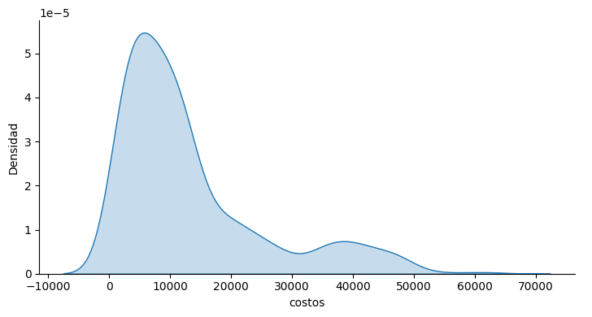

```python
#Distribución de la Variable a Predecir
def distVarPred(data:pd.DataFrame, var:str): #, variable_predict:str):
  g = sns.FacetGrid(data, height = 4, aspect = 1.8) #, hue = variable_predict)
  g = g.map(sns.kdeplot, var, fill = True)
  g = g.add_legend()

  g.set_ylabels("Densidad")

  return(g)

distVarPred(df, 'costos')
```

### Poder Predictivo

```python
def poder_predictivo_numerica(data:pd.DataFrame, var:str, variable_predict:str):
  g = sns.FacetGrid(data, height = 4, aspect = 1.8, hue = variable_predict)
  g = g.map(sns.kdeplot, var, fill = True)
  g = g.add_legend()

  g.set_ylabels("Densidad")

  return(g)
```

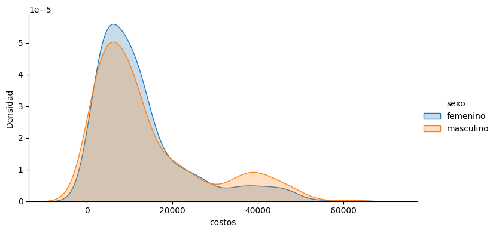

```python
poder_predictivo_numerica(df, 'costos', 'sexo')
```

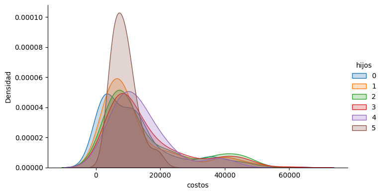

```python
poder_predictivo_numerica(df, 'costos', 'hijos')
```

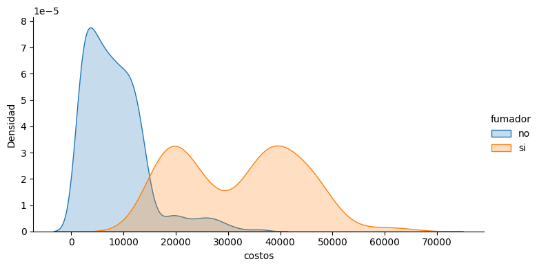

```python
poder_predictivo_numerica(df, 'costos', 'fumador')
```

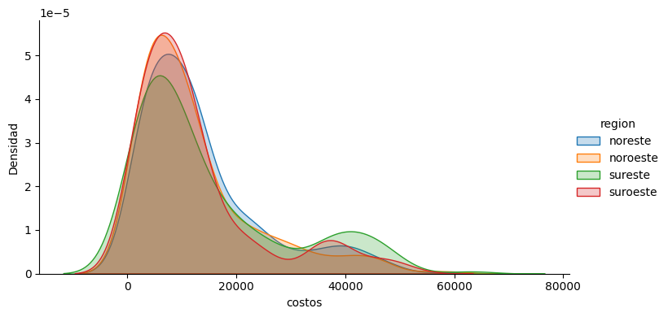

```python
poder_predictivo_numerica(df, 'costos', 'region')
```

Costos variable a predecir.  
Con un total de 1338 filas, una mediana de 9382.033, con un promedio de 13270.422, los datos se alejan/acercan 12110.011 del promedio, los costos mínimos son de 1121.873, los máximos de 63770.428, para un rango de 62648.554, mantiene una moda de 1639.563. Su 1er Cuartil (25%) es de 4740.287, su 3er Cuartil (75%) de 16639.912, con un rango intercuartíl de 11899.625 y un total de costos de 17755824.990

## Parte 2

- b) Genere todos los métodos de regresión en Python vistos en clase para generar modelos de regresión usando el 85% de los datos para la tabla aprendizaje y un 15% para la tabla testing.

### **División train-test**

```python
X = df.drop(columns=['costos'])
X.head(3)
```

|  | edad | sexo | imc | hijos | fumador | region |
| --- | --- | --- | --- | --- | --- | --- |
| 0 | 19 | femenino | 27.90 | 0 | si | suroeste |
| 1 | 18 | masculino | 33.77 | 1 | no | sureste |
| 2 | 28 | masculino | 33.00 | 3 | no | sureste |

```python
y = df['costos'].to_numpy()
y[0:6]
```

```
array([16884.924  ,  1725.5523 ,  4449.462  , 21984.47061,  3866.8552 ,
        3756.6216 ])
```

```python
# X_train, X_test, y_train, y_test = train_test_split(X, y, test_size=0.15)
```

```python
# Clasificación de variables entre categóricas y númericas
var_categoricas = 'sexo', 'fumador', 'region'
var_numericas = 'edad', 'imc', 'hijos'
```

### **Modelado y Preprocesamiento**

```python
def modelado(X, y, var_categoricas, var_numericas, modelo_predictorio, test_size=0.15):
    X_train, X_test, y_train, y_test = train_test_split(X, y, test_size=test_size)

    preprocesamiento = ColumnTransformer(
        transformers=[
            ('cat', OneHotEncoder(), var_categoricas),
            ('num', StandardScaler(), var_numericas)
    ])

    modelo = Pipeline(steps=[
        ('preprocesador', preprocesamiento),
        ('clasificador', modelo_predictorio)
    ])

    modelo.fit(X_train, y_train)
    pred = modelo.predict(X_test)

    rmse = np.sqrt(np.mean((y_test - pred) ** 2))
    mae = np.mean(np.abs(y_test - pred))
    er = np.sum(np.abs(y_test - pred)) / np.sum(np.abs(y_test))


    diccionario = {
        'Modelo': modelo,
        'Error Cuadrático Medio (RMSE)': rmse,
        'Error Absoluto Medio (MAE)': mae,
        'Error Relativo (ER)': er
    }

    return diccionario
```

```python
def imprimir_resultados(resultado, nombre_modelo):
    modelo_entrenado = resultado['Modelo']

    df_metricas = pd.DataFrame({
        'Modelo': [nombre_modelo],
        'RMSE': [resultado['Error Cuadrático Medio (RMSE)']],
        'MAE': [resultado['Error Absoluto Medio (MAE)']],
        'ER': [resultado['Error Relativo (ER)']]
    })
    # df_metricas['Modelo'] = nombre_modelo

    return df_metricas
```

### LinearRegression

```python
# resultado guarda el modelo
resultado_lrm = modelado(X, y, var_categoricas, var_numericas, modelo_predictorio=LinearRegression(), test_size=0.15)

# imprimen loas resultado del modelo
lrm_metrics_df = imprimir_resultados(resultado_lrm, 'LinearRegression')
lrm_metrics_df
```

|  | Modelo | RMSE | MAE | ER |
| --- | --- | --- | --- | --- |
| 0 | LinearRegression | 6254.405255 | 4067.118461 | 0.310649 |

### LassoRegression

**Buscando el mejor alfa, con Lasso Cross-Validation**

```python
X_train, X_test, y_train, y_test = train_test_split(X, y, test_size=0.15)

rango_alfa = np.logspace(-6, 6, 200)
preprocesamiento = ColumnTransformer(
    transformers=[
        ('cat', OneHotEncoder(sparse_output = False), var_categoricas),
        ('num', StandardScaler(), var_numericas)
])

modelo = Pipeline(steps=[
    ('preprocesador', preprocesamiento),
    ('clasificador', LassoCV(alphas = rango_alfa))
])

modelo.fit(X_train, y_train)
pred = modelo.predict(X_test)

mejor_alfa = modelo['clasificador'].alpha_
mejor_alfa
```

```
np.float64(69.05513520162316)
```

**Coeficientes**

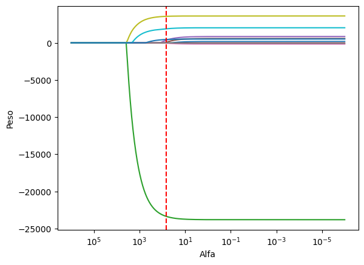

```python
coefs = []
for a in rango_alfa:
  lasso = Pipeline(steps=[
    ('preprocesador', preprocesamiento),
    ('clasificador', Lasso(alpha = a, fit_intercept = True))
  ])
  no_print = lasso.fit(X_train, y_train)
  coefs.append(lasso['clasificador'].coef_)

ax = plt.gca()
no_plot = ax.plot(rango_alfa, coefs)
no_plot = ax.set_xscale("log")
no_plot = ax.set_xlim(ax.get_xlim()[::-1])
no_plot = plt.xlabel("Alfa")
no_plot = plt.ylabel("Peso")
no_plot = plt.axis("tight")
no_plot = plt.axvline(x = mejor_alfa, color = 'r', linestyle = '--', label = f'Mejor alfa: {mejor_alfa}')
plt.show()
```

```python
# resultado guarda el modelo
resultado_lr = modelado(X, y, var_categoricas, var_numericas, modelo_predictorio = Lasso(alpha = mejor_alfa), test_size=0.15)
resultado_lr

# imprimen los resultado del modelo
lr_metrics_df = imprimir_resultados(resultado_lr, 'LassoRegression')
lr_metrics_df
```

|  | Modelo | RMSE | MAE | ER |
| --- | --- | --- | --- | --- |
| 0 | LassoRegression | 6535.275219 | 4510.538008 | 0.353268 |

### RidgeRegression

- `alpha`: Constante que multiplica el término L2, controlando la fuerza de regularización. Alfa debe ser un flotante no negativo, es decir, en [0, inf). Cuando `alfa = 0`, el objetivo es equivalente a la regresión lineal, resuelto por el objeto `LinearRegression`. Por razones numéricas, no se recomienda usar `alpha = 0` con el objeto `Ridge`. En su lugar, debe usar el objeto `LinearRegression`.
- `fit_interceptbool`: Si se establece en falso, no se utilizará ningun intercepto en los cálculos (es decir, se espera que X e y estén centrados). `default = True
- `solver`: {`auto`, `svd`, `cholesky`, `lsqr`, `sparse_cg`, `sag`, `saga`, `lbfgs`}, *default='auto'* Solver para usar en las rutinas computacionales:
- `auto`: elige el solucionador automáticamente según el tipo de datos.
- `svd`: utiliza una Descomposición de valor singular de X para calcular los coeficientes de Ridge. Es el solucionador más estable, en particular más estable para matrices singulares que `cholesky` a costa de ser más lento.
- `cholesky`: usa la función estándar scipy.linalg.solve para obtener una solución de forma cerrada.
- `sparse_cg`: usa el solucionador de gradiente conjugado que se encuentra en scipy.sparse.linalg.cg. Como algoritmo iterativo, este solucionador es más apropiado que `cholesky` para datos a gran escala (posibilidad de configurar toly `max_iter`).
- `lsqr`: usa la rutina dedicada de mínimos cuadrados regularizados scipy.sparse.linalg.lsqr. Es el más rápido y utiliza un procedimiento iterativo.
- `sag`: usa un descenso de gradiente promedio estocástico, y ‘saga’ usa su versión mejorada e imparcial llamada SAGA. Ambos métodos también utilizan un procedimiento iterativo y, a menudo, son más rápidos que otros solucionadores cuando tanto n_samples como n_features son grandes. Tenga en cuenta que la convergencia rápida ‘sag’ y ‘saga’ solo está garantizada en entidades con aproximadamente la misma escala. Puede preprocesar los datos con un escalador de sklearn.preprocessing.
- `lbfgs`: usa el algoritmo L-BFGS-B implementado en scipy.optimize.minimize. Solo se puede usar cuando positive es Verdadero.

**Buscando el mejor alfa, con Ridge Cross-Validation**

```python
X_train, X_test, y_train, y_test = train_test_split(X, y, test_size=0.15)

preprocesamiento = ColumnTransformer(
    transformers=[
        ('cat', OneHotEncoder(), var_categoricas),
        ('num', StandardScaler(), var_numericas)
])

modelo = Pipeline(steps=[
    ('preprocesador', preprocesamiento),
    ('clasificador', RidgeCV(alphas = rango_alfa))#, store_cv_values = True))
])

modelo.fit(X_train, y_train)
pred = modelo.predict(X_test)

mejor_alfa = modelo['clasificador'].alpha_
mejor_alfa
```

```
np.float64(0.9329304026284677)
```

**Coeficientes**

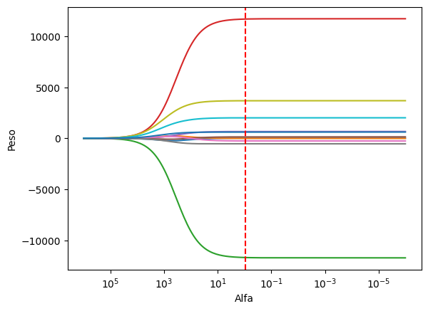

```python
coefs = []
for a in rango_alfa:
  ridge = Pipeline(steps=[
    ('preprocesador', preprocesamiento),
    ('clasificador', Ridge(alpha = a, fit_intercept = True))
  ])
  no_print = ridge.fit(X_train, y_train)
  coefs.append(ridge['clasificador'].coef_)

ax = plt.gca()
no_plot = ax.plot(rango_alfa, coefs)
no_plot = ax.set_xscale("log")
no_plot = ax.set_xlim(ax.get_xlim()[::-1])
no_plot = plt.xlabel("Alfa")
no_plot = plt.ylabel("Peso")
no_plot = plt.axis("tight")
no_plot = plt.axvline(x = mejor_alfa, color = 'r', linestyle = '--', label = f'Mejor alfa: {mejor_alfa}')
plt.show()
```

```python
# ridgeCV_con_parametros = RidgeCV(alphas = np.logspace(-6, 6, 200)), store_cv_values = True)
# resultado guarda el modelo
resultado_ridge = modelado(X, y, var_categoricas, var_numericas, modelo_predictorio = Ridge(alpha = mejor_alfa), test_size=0.15)

# imprimen loas resultado del modelo
ridge_metrics_df = imprimir_resultados(resultado_ridge, 'RidgeRegression')
ridge_metrics_df
```

|  | Modelo | RMSE | MAE | ER |
| --- | --- | --- | --- | --- |
| 0 | RidgeRegression | 5607.744803 | 3819.016769 | 0.288582 |

### SVM

- `kernel`: `{'linear', 'poly', 'rbf', 'sigmoid', 'precomputed'}` Especifica el nucleo que usa el algoritmo. Si no se especifica se usa `'rbf'` por defecto.
- `degree`: int, *default=3* Grado de la función kernel polinomial (`'poly'`). Debe ser no negativo. Es ignorado por todos los demás núcleos.
- `tol`: float, *default=1e-3* Tolerancia para el criterio de parada.
- `C`: float, *default=1.0* Parámetro de regularización. La fuerza de la regularización es inversamente proporcional a `C`. Debe ser estrictamente positiva. La penalización es una penalización de l2 al cuadrado.
- `epsilon`: float, *default=0.1* Epsilon en el modelo epsilon-SVR. Especifica el tubo épsilon dentro del cual no se asocia ninguna penalización en la función de pérdida de entrenamiento con puntos predichos dentro de una distancia épsilon del valor real. Debe ser no negativo.

```python
# svm_con_parametros = SVR(kernel = "rbf", C = 100, epsilon = 0.1)
# resultado guarda el modelo
resultado_svm = modelado(X, y, var_categoricas, var_numericas, modelo_predictorio = SVR(kernel = "rbf", C = 100, epsilon = 0.1), test_size=0.15)

# imprimen loas resultado del modelo
svm_metrics_df = imprimir_resultados(resultado_svm, 'SupportVectorMachine')
svm_metrics_df
```

|  | Modelo | RMSE | MAE | ER |
| --- | --- | --- | --- | --- |
| 0 | SupportVectorMachine | 9259.796894 | 4395.6315 | 0.38585 |

### DecisionTreeRegressor

- `max_depth`: profundidad máxima que puede alcanzar el árbol.
- `min_samples_split`: número mínimo de observaciones que debe de tener un nodo para que pueda dividirse. Si es un valor decimal se interpreta como fracción del total de observaciones de entrenamiento `ceil(min_samples_split * n_samples)`.
- `min_samples_leaf`: número mínimo de observaciones que debe de tener cada uno de los nodos hijos para que se produzca la división. Si es un valor decimal se interpreta como fracción del total de observaciones de entrenamiento `ceil(min_samples_split * n_samples)`.
- `max_leaf_nodes`: número máximo de nodos terminales.

```python
# dtr_con_parametros = DecisionTreeRegressor(max_depth = 3)
# resultado guarda el modelo
resultado_dtr = modelado(X, y, var_categoricas, var_numericas, modelo_predictorio = DecisionTreeRegressor(max_depth = 3), test_size=0.15)

# imprimen loas resultado del modelo
dtr_metrics_df = imprimir_resultados(resultado_dtr, 'DecisionTreeRegressor')
dtr_metrics_df
```

|  | Modelo | RMSE | MAE | ER |
| --- | --- | --- | --- | --- |
| 0 | DecisionTreeRegressor | 4816.562872 | 2820.199238 | 0.210757 |

### RandomForestRegressor

- `n_estimators`: int, `default=100`. Número de árboles en el bosque.
- `criterion`: {`'squared_error'`, `'absolute_error'`, `'friedman_mse'`, `'poisson'`}, *default='squared_error'*. La función para medir la calidad de una división. Los criterios admitidos son:
  - `'squared_error'` para el error cuadrático medio, que es igual a la reducción de la varianza como criterio de selección de características y minimiza la pérdida de L2 utilizando la media de cada nodo terminal,
  - `'friedman_mse'`, que utiliza el error cuadrático medio con la puntuación de mejora de Friedman para el potencial splits,
  - `'absolute_error'` para el error absoluto medio, que minimiza la pérdida L1 usando la mediana de cada nodo terminal, y
  - `'poisson'` que usa la reducción en la desviación de Poisson para encontrar divisiones. El entrenamiento con `'absolute_error'` es significativamente más lento que cuando se usa `'squared_error'`.
- `max_depth`: int, *default=None*. La profundidad máxima del árbol. Si es None, los nodos se expanden hasta que todas las hojas sean puras o hasta que todas las hojas contengan menos de `min_samples_split` samples.
- `min_samples_split`: int o float, *default=2*. El número mínimo de muestras requeridas para dividir un nodo interno.

```python
# rfr_con_parametros = RandomForestRegressor(n_estimators = 50, max_depth = 2)
# resultado guarda el modelo
resultado_rfr = modelado(X, y, var_categoricas, var_numericas, modelo_predictorio = RandomForestRegressor(n_estimators = 50, max_depth = 2), test_size=0.15)

# imprimen loas resultado del modelo
rfr_metrics_df = imprimir_resultados(resultado_rfr, 'RandomForestRegressor')
rfr_metrics_df
```

|  | Modelo | RMSE | MAE | ER |
| --- | --- | --- | --- | --- |
| 0 | RandomForestRegressor | 4689.750498 | 3028.341652 | 0.248377 |

### GradientBoostingRegressor

- `n_estimators`: int, *default=100*. El número de etapas de refuerzo a realizar. El descenso del gradiente es bastante resistente al sobreajuste, por lo que un gran número generalmente da como resultado un mejor rendimiento. Los valores deben estar en el rango [1, inf)
- `min_samples_leaf`: int o float, Por *defecto = 1*. El número mínimo de muestras requeridas para estar en un nodo hoja. Un punto de división a cualquier profundidad solo se considerará si deja al menos min_sampleser el modelo.
- `max_depth`: int o None, *default = 3*. Profundidad máxima de los estimadores de regresión individuales. La profundidad máxima limita el número de nodos en el árbol. Ajuste este parámetro para obtener el mejor rendimiento; el mejor valor depende de la interacción de las variables predictoras. Si es None, los nodos se expanden hasta que todas las hojas sean puras o hasta que todas las hojas contengan menos de `min_samples_split` samples. Si es int, los valores deben estar en el rango [1, inf).

```python
# gb_con_parametros = GradientBoostingRegressor(n_estimators = 50, max_depth = 2)
# resultado guarda el modelo
resultado_gb = modelado(X, y, var_categoricas, var_numericas, modelo_predictorio = GradientBoostingRegressor(n_estimators = 50, max_depth = 2), test_size=0.15)

# imprimen loas resultado del modelo
gb_metrics_df = imprimir_resultados(resultado_gb, 'GradientBoostingRegressor')
gb_metrics_df
```

|  | Modelo | RMSE | MAE | ER |
| --- | --- | --- | --- | --- |
| 0 | GradientBoostingRegressor | 4885.352501 | 2756.558138 | 0.199445 |

## Parte 3

- c) Construya un DataFrame que compare los modelos generados en el ítem anterior. Para esto en cada una de las filas debe aparecer un modelo predictivo y en las columnas aparezcan los índices Raíz del error cuadrático medio, Error relativo y Error absoluto medio e interprete los resultados.

Cuál de los modelos es mejor para estos datos y por qué?, recuerde que debe comparar contra el resumen numérico de la variable a predecir.

```python
medicion_error = pd.concat([lrm_metrics_df, lr_metrics_df, ridge_metrics_df, svm_metrics_df, dtr_metrics_df, rfr_metrics_df, gb_metrics_df])
medicion_error
```

|  | Modelo | RMSE | MAE | ER |
| --- | --- | --- | --- | --- |
| 0 | LinearRegression | 6254.405255 | 4067.118461 | 0.310649 |
| 0 | LassoRegression | 6535.275219 | 4510.538008 | 0.353268 |
| 0 | RidgeRegression | 5607.744803 | 3819.016769 | 0.288582 |
| 0 | SupportVectorMachine | 9259.796894 | 4395.631500 | 0.385850 |
| 0 | DecisionTreeRegressor | 4816.562872 | 2820.199238 | 0.210757 |
| 0 | RandomForestRegressor | 4689.750498 | 3028.341652 | 0.248377 |
| 0 | GradientBoostingRegressor | 4885.352501 | 2756.558138 | 0.199445 |

### **Interpretación**

- Los mejores modelos son:
  - `RandomForestRegressor`con **RMSE**: 4689.75, **MAE**: 3028.34 y **ER**: 0.248
  - `DecisionTreeRegressor` con **RMSE**: 4816.56, **MAE**: 2820.19, y **ER**: 0.210
  - `GradientBoostingRegressor` con **RMSE**:4885.35, **MAE**:2756.55, y **ER**:0.199
- Ahora teniendo en cuenta la distribución de la variable `costos`, el modelo `GradientBoostingRegressor` es el mas adecuado, por que su RMSE (4885.35) es mas bajo que la desviación stardard(12110.01), un MAE (2756.55) bajo en comparación con el promedio (13270.42) modelo robusto frente a una dispersión y un ER bastante mas bajo que el resto de modelos, que implica qe solo se desvia en promedio 19.9%

# Ejercicio 2

[50 puntos] En este ejercicio se usará la tabla de datos `Melbourne_CasasV3.csv`. Este conjunto de datos contiene los precios de algunas casas en Melbourne que es la capital del estado australiano de Victoria y es la ciudad más poblada de Australia y Oceanía. Además, se cree que Melbourne actualmente está experimentando una burbuja inmobiliaria (algunos expertos dicen que podría estallar pronto).  
Quizás alguien pueda encontrar una tendencia o dar una predicción?

La descripción de las variables son las siguientes:

- `Rooms`: Número de habitaciones.
- `Price`: Precio en cientos de dólares australianos (Variable a predecir).
- `Method`:
  - S - propiedad vendida;
  - SP - propiedad vendida antes;
  - PI - propiedad pasada;
  - PN - vendido antes no divulgado;
  - SN - vendido no divulgado;
  - NB - sin oferta;
  - VB - oferta del vendedor;
  - W - retirado antes de la subasta;
  - SA - vendido después de una subasta;
  - SS - vendido después del precio de la subasta no revelado.
  - N/A: el precio o la oferta más alta no están disponibles.
- `Type`:
  - br - dormitorio(s);
  - h - casa, cabaña, villa, semi, terraza;
  - u - unidad, dúplex;
  - t - casa adosada;
  - sitio dev - sitio de desarrollo;
  - o res - otros residenciales.
- `Distance`: Distancia desde CDB en Kilómetros.
- `Propertycount`: Número de propiedades que existen en el suburbio(Debe eliminarse esta variable.).
- `Bedroom2`: Número raspado de dormitorios (de una fuente diferente).
- `Bathroom`: Número de Bañnos.
- `Postcode`: Código postal.
- `Car`: Número de aparcamientos.
- `Landsize`: Tamañno del terreno en metros.
- `BuildingArea`: Tamañno del edificio en metros.
- `YearBuilt`: Añno en que se construyó la casa.
- `Latitud`: Latitud.
- `Longitud`: Longitud.

Realice lo siguiente:

- a) Cargue la tabla de datos `Melbourne_CasasV3.csv`, verifique su correcta lectura y elimine las filas con valores faltantes si los hubiera.
- b) Genere todos los métodos de regresión en Python vistos en clase para generar modelos de regresión para la tabla usando el 80% de los datos para la tabla aprendizaje y un 20% para la tabla testing. En particular para el método Máquinas de Soporte Vectorial use todos los núcleos de la presentación es decir: linear, poly, rbf.
- c) Construya un DataFrame que compare los modelos generados en elítem anterior. Para esto en cada una de las filas debe aparecer un modelo predictivo y en las columnas aparezcan los índices Raíz del error cuadrático medio, Error relativo y Error absoluto medio e interprete los resultados.

Cuál de los modelos es mejor para estos datos y por qué?, recuerde que debe comparar contra el resumen numérico de la variable a predecir.

↑ Volver al Menú

## Parte 1

- a) Cargue la tabla de datos `melbourne_casas_v3.csv`, verifique su correcta lectura y elimine las filas con valores faltantes si los hubiera.

```python
df = pd.read_csv('data/melbourne_casas_v3.csv', delimiter = ',', decimal = ".", index_col = 0)
df.head(3)
```

|  | Rooms | Type | Price | Method | Distance | Postcode | Bedroom2 | Bathroom | Car | Landsize | BuildingArea | YearBuilt | Lattitude | Longtitude | Propertycount |
| --- | --- | --- | --- | --- | --- | --- | --- | --- | --- | --- | --- | --- | --- | --- | --- |
| 7750 | 3 | h | 7.00 | S | 9.9 | 3044 | 3 | 1 | 2 | 449 | 104.0 | 1950.0 | -37.72860 | 144.94560 | 7485 |
| 14816 | 2 | h | 13.15 | S | 5.2 | 3056 | 2 | 1 | 1 | 234 | 106.0 | 1910.0 | -37.77539 | 144.95576 | 11918 |
| 12482 | 3 | t | 9.75 | VB | 11.7 | 3125 | 3 | 2 | 2 | 267 | 150.0 | 2012.0 | -37.84630 | 145.10710 | 5678 |

```python
df.shape
```

```
(2500, 15)
```

```python
df.info()
```

```
<class 'pandas.core.frame.DataFrame'>
Index: 2500 entries, 7750 to 9300
Data columns (total 15 columns):
 #   Column         Non-Null Count  Dtype
---  ------         --------------  -----
 0   Rooms          2500 non-null   int64
 1   Type           2500 non-null   object
 2   Price          2500 non-null   float64
 3   Method         2500 non-null   object
 4   Distance       2500 non-null   float64
 5   Postcode       2500 non-null   int64
 6   Bedroom2       2500 non-null   int64
 7   Bathroom       2500 non-null   int64
 8   Car            2500 non-null   int64
 9   Landsize       2500 non-null   int64
 10  BuildingArea   2500 non-null   float64
 11  YearBuilt      2500 non-null   float64
 12  Lattitude      2500 non-null   float64
 13  Longtitude     2500 non-null   float64
 14  Propertycount  2500 non-null   int64
dtypes: float64(6), int64(7), object(2)
memory usage: 312.5+ KB
```

```python
df.isnull().sum()
```

```
Rooms            0
Type             0
Price            0
Method           0
Distance         0
Postcode         0
Bedroom2         0
Bathroom         0
Car              0
Landsize         0
BuildingArea     0
YearBuilt        0
Lattitude        0
Longtitude       0
Propertycount    0
dtype: int64
```

```python
df_v2 = df.copy()
```

```python
df_v2['Type'] = df_v2['Type'].astype('category')
df_v2['Method'] = df_v2['Method'].astype('category')
df_v2['Postcode'] = df_v2['Postcode'].astype('category')

df_v2 = df_v2.drop(columns=['Propertycount'])
# Propertycount  2500 non-null   int64 -> remove
# Price -> target
df_v2.info()
```

```
<class 'pandas.core.frame.DataFrame'>
Index: 2500 entries, 7750 to 9300
Data columns (total 14 columns):
 #   Column        Non-Null Count  Dtype
---  ------        --------------  -----
 0   Rooms         2500 non-null   int64
 1   Type          2500 non-null   category
 2   Price         2500 non-null   float64
 3   Method        2500 non-null   category
 4   Distance      2500 non-null   float64
 5   Postcode      2500 non-null   category
 6   Bedroom2      2500 non-null   int64
 7   Bathroom      2500 non-null   int64
 8   Car           2500 non-null   int64
 9   Landsize      2500 non-null   int64
 10  BuildingArea  2500 non-null   float64
 11  YearBuilt     2500 non-null   float64
 12  Lattitude     2500 non-null   float64
 13  Longtitude    2500 non-null   float64
dtypes: category(3), float64(6), int64(5)
memory usage: 249.9 KB
```

**Distribución de Variable a Predecir**

```python
df_v2['Price'].describe()
```

```
count    2500.000000
mean        9.553838
std         4.403229
min         1.310000
25%         6.150000
50%         8.600000
75%        12.500000
max        22.300000
Name: Price, dtype: float64
```

```python
distVariableToBePredicted(df_v2['Price'])
```

```
{'Moda': np.float64(6.0),
 'Suma/Total': np.float64(23884.595930000003),
 'Rango': np.float64(20.990000000000002),
 'Rango Intercuartil': np.float64(6.35),
 'Varianza': np.float64(19.388427243860292)}
```

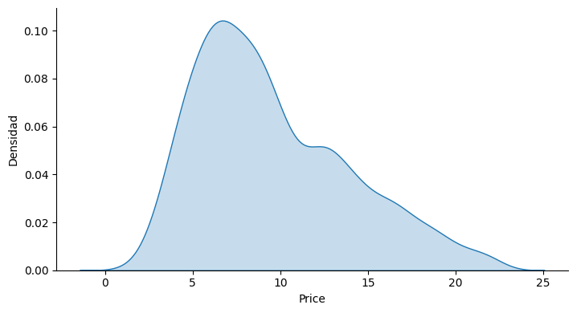

```python
distVarPred(df_v2, 'Price')
```

### Poder Predictivo

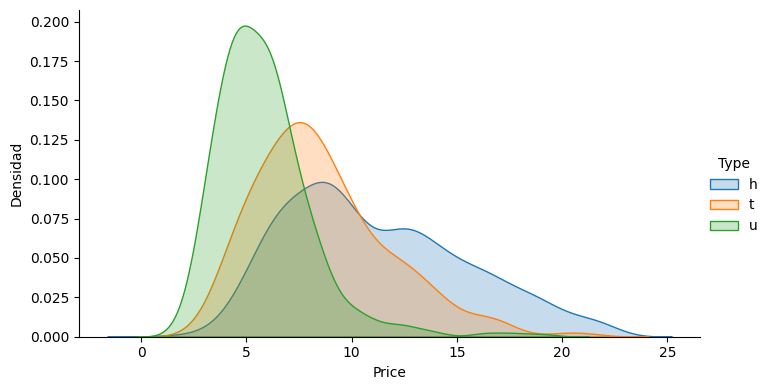

```python
poder_predictivo_numerica(df_v2, 'Price', 'Type') #'Type', 'Method', 'Postcode'
```

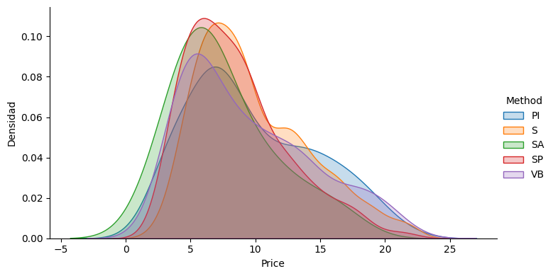

```python
poder_predictivo_numerica(df_v2, 'Price', 'Method') #'Type', 'Method', 'Postcode'
```

## Parte 2

- b) Genere todos los métodos de regresión en Python vistos en clase para generar modelos de regresión para la tabla usando el 80% de los datos para la tabla aprendizaje y un 20% para la tabla testing. En particular para el método Máquinas de Soporte Vectorial use todos los núcleos de la presentación es decir: linear, poly, rbf.

### Division Train-Test

```python
X = df_v2.drop(columns=['Price'])
X.head(3)
```

|  | Rooms | Type | Method | Distance | Postcode | Bedroom2 | Bathroom | Car | Landsize | BuildingArea | YearBuilt | Lattitude | Longtitude |
| --- | --- | --- | --- | --- | --- | --- | --- | --- | --- | --- | --- | --- | --- |
| 7750 | 3 | h | S | 9.9 | 3044 | 3 | 1 | 2 | 449 | 104.0 | 1950.0 | -37.72860 | 144.94560 |
| 14816 | 2 | h | S | 5.2 | 3056 | 2 | 1 | 1 | 234 | 106.0 | 1910.0 | -37.77539 | 144.95576 |
| 12482 | 3 | t | VB | 11.7 | 3125 | 3 | 2 | 2 | 267 | 150.0 | 2012.0 | -37.84630 | 145.10710 |

```python
y = df_v2['Price'].to_numpy()
y[0:6]
```

```
array([ 7.  , 13.15,  9.75,  8.8 ,  5.4 ,  3.3 ])
```

```python
# X_test, X_train, y_test, y_train = train_test_split(X, y, train_size=0.8)
var_numericas ='Rooms', 'Distance', 'Bedroom2', 'Bathroom', 'Car', 'Landsize', 'BuildingArea', 'YearBuilt', 'Lattitude', 'Longtitude', 'Postcode'
var_categoricas = 'Type', 'Method'#, 'Postcode'
```

**Modelado y Preprocesamiento**

### LinearRegression

```python
# resultado guarda el modelo
resultado_lrm = modelado(X, y, var_categoricas = var_categoricas, var_numericas = var_numericas, modelo_predictorio=LinearRegression(), test_size=0.20)

# imprimen loas resultado del modelo
lrm_metrics_df = imprimir_resultados(resultado_lrm, 'LinearRegression')
lrm_metrics_df
```

|  | Modelo | RMSE | MAE | ER |
| --- | --- | --- | --- | --- |
| 0 | LinearRegression | 2.95797 | 2.120256 | 0.220788 |

### LassoRegression

```python
X_train, X_test, y_train, y_test = train_test_split(X, y, test_size=0.2)

rango_alfa = np.logspace(-6, 6, 200)
preprocesamiento = ColumnTransformer(
    transformers=[
        ('cat', OneHotEncoder(sparse_output = False), var_categoricas),
        ('num', StandardScaler(), var_numericas)
])

modelo = Pipeline(steps=[
    ('preprocesador', preprocesamiento),
    ('clasificador', LassoCV(alphas = rango_alfa))
])

modelo.fit(X_train, y_train)
pred = modelo.predict(X_test)

mejor_alfa = modelo['clasificador'].alpha_
mejor_alfa
```

```
np.float64(0.07663410868007446)
```

**Coeficientes**

[output not shown]

[output cut: 15 more lines]

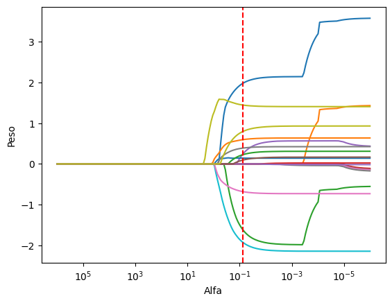

```python
coefs = []
for a in rango_alfa:
  lasso = Pipeline(steps=[
    ('preprocesador', preprocesamiento),
    ('clasificador', Lasso(alpha = a, fit_intercept = True))
  ])
  no_print = lasso.fit(X_train, y_train)
  coefs.append(lasso['clasificador'].coef_)

ax = plt.gca()
no_plot = ax.plot(rango_alfa, coefs)
no_plot = ax.set_xscale("log")
no_plot = ax.set_xlim(ax.get_xlim()[::-1])
no_plot = plt.xlabel("Alfa")
no_plot = plt.ylabel("Peso")
no_plot = plt.axis("tight")
no_plot = plt.axvline(x = mejor_alfa, color = 'r', linestyle = '--', label = f'Mejor alfa: {mejor_alfa}')
plt.show()
```

```python
# resultado guarda el modelo
resultado_lr = modelado(X, y, var_categoricas, var_numericas, modelo_predictorio = Lasso(alpha = mejor_alfa), test_size=0.15)
resultado_lr

# imprimen los resultado del modelo
lr_metrics_df = imprimir_resultados(resultado_lr, 'LassoRegression')
lr_metrics_df
```

|  | Modelo | RMSE | MAE | ER |
| --- | --- | --- | --- | --- |
| 0 | LassoRegression | 3.045483 | 2.284787 | 0.23615 |

### RidgeRegression

**Buscando el mejor alfa, con Ridge Cross-Validation**

```python
X_train, X_test, y_train, y_test = train_test_split(X, y, test_size=0.2)

preprocesamiento = ColumnTransformer(
    transformers=[
        ('cat', OneHotEncoder(), var_categoricas),
        ('num', StandardScaler(), var_numericas)
])

modelo = Pipeline(steps=[
    ('preprocesador', preprocesamiento),
    ('clasificador', RidgeCV(alphas = rango_alfa))#, store_cv_values = True))
])

modelo.fit(X_train, y_train)
pred = modelo.predict(X_test)

mejor_alfa = modelo['clasificador'].alpha_
mejor_alfa
```

```
np.float64(69.05513520162316)
```

**Coeficientes**

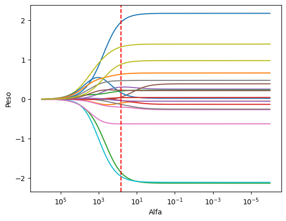

```python
coefs = []
for a in rango_alfa:
  ridge = Pipeline(steps=[
    ('preprocesador', preprocesamiento),
    ('clasificador', Ridge(alpha = a, fit_intercept = True))
  ])
  no_print = ridge.fit(X_train, y_train)
  coefs.append(ridge['clasificador'].coef_)

ax = plt.gca()
no_plot = ax.plot(rango_alfa, coefs)
no_plot = ax.set_xscale("log")
no_plot = ax.set_xlim(ax.get_xlim()[::-1])
no_plot = plt.xlabel("Alfa")
no_plot = plt.ylabel("Peso")
no_plot = plt.axis("tight")
no_plot = plt.axvline(x = mejor_alfa, color = 'r', linestyle = '--', label = f'Mejor alfa: {mejor_alfa}')
plt.show()
```

```python
# resultado guarda el modelo
resultado_ridge = modelado(X, y, var_categoricas, var_numericas, modelo_predictorio = Ridge(alpha = mejor_alfa), test_size=0.15)

# imprimen loas resultado del modelo
ridge_metrics_df = imprimir_resultados(resultado_ridge, 'RidgeRegression')
ridge_metrics_df
```

|  | Modelo | RMSE | MAE | ER |
| --- | --- | --- | --- | --- |
| 0 | RidgeRegression | 2.962996 | 2.139554 | 0.231841 |

### SVM

```python
# resultado guarda el modelo
resultado_svm_linear = modelado(X, y, var_categoricas, var_numericas, modelo_predictorio = SVR(kernel = "linear", C = 100, epsilon = 0.1), test_size=0.2)

# imprimen loas resultado del modelo
svm_metrics_df_linear = imprimir_resultados(resultado_svm_linear, 'SupportVectorMachine_linear')
svm_metrics_df_linear
```

|  | Modelo | RMSE | MAE | ER |
| --- | --- | --- | --- | --- |
| 0 | SupportVectorMachine_linear | 2.626208 | 1.97928 | 0.214398 |

```python
# resultado guarda el modelo
resultado_svm_poly = modelado(X, y, var_categoricas, var_numericas, modelo_predictorio = SVR(kernel = "poly", C = 100, epsilon = 0.1), test_size=0.2)

# imprimen loas resultado del modelo
svm_metrics_df_poly = imprimir_resultados(resultado_svm_poly, 'SupportVectorMachine_poly')
svm_metrics_df_poly
```

|  | Modelo | RMSE | MAE | ER |
| --- | --- | --- | --- | --- |
| 0 | SupportVectorMachine_poly | 7.141264 | 2.798324 | 0.29783 |

```python
# resultado guarda el modelo
resultado_svm_rbf = modelado(X, y, var_categoricas, var_numericas, modelo_predictorio = SVR(kernel = "rbf", C = 100, epsilon = 0.1), test_size=0.2)

# imprimen loas resultado del modelo
svm_metrics_df_rbf = imprimir_resultados(resultado_svm_rbf, 'SupportVectorMachine_rbf')
svm_metrics_df_rbf
```

|  | Modelo | RMSE | MAE | ER |
| --- | --- | --- | --- | --- |
| 0 | SupportVectorMachine_rbf | 2.33266 | 1.64777 | 0.172402 |

```python
# resultado guarda el modelo
resultado_svm_sigmoid = modelado(X, y, var_categoricas, var_numericas, modelo_predictorio = SVR(kernel = "sigmoid", C = 100, epsilon = 0.1), test_size=0.2)

# imprimen loas resultado del modelo
svm_metrics_df_sigmoid = imprimir_resultados(resultado_svm_sigmoid, 'SupportVectorMachine_sigmoid')
svm_metrics_df_sigmoid
```

|  | Modelo | RMSE | MAE | ER |
| --- | --- | --- | --- | --- |
| 0 | SupportVectorMachine_sigmoid | 1498.871199 | 660.186276 | 67.244837 |

### SVM con computed

- debemos transformar los datos originales en una Matriz de Similitud antes de entrenar.

```python
# Convertir variables categóricas (Method y Type) a números
df_processed = pd.get_dummies(df, columns=['Method', 'Type'])

# Separar X e y
X_svm = df_processed.drop(columns=['Price','Propertycount'])
y_svm = df_processed['Price']

# División real: 80% entrenamiento (2000 filas), 20% prueba (500 filas)
X_train_raw, X_test_raw, y_train, y_test = train_test_split(X_svm, y_svm, test_size=0.2, random_state=42)

scaler = StandardScaler()

# Ajustamos el escalador SOLO con los datos de entrenamiento
X_train_scaled = scaler.fit_transform(X_train_raw)

# Transformamos los datos de prueba con ese mismo escalador
X_test_scaled = scaler.transform(X_test_raw)

# Calculamos el kernel lineal manualmente: K = X * X_transpuesta
K_train = np.dot(X_train_scaled, X_train_scaled.T)

# Entrenamos el SVR
model = SVR(kernel='precomputed', C=100, epsilon=0.1)
model.fit(K_train, y_train)

# Generamos la matriz de relación (500 filas de test x 2000 columnas de train)
K_test = np.dot(X_test_scaled, X_train_scaled.T)

# Ahora sí, predecimos
pred = model.predict(K_test)
```

```python
def errores_svr_cumputed(y_test, pred):
    rmse = np.sqrt(np.mean((y_test - pred) ** 2))
    mae = np.mean(np.abs(y_test - pred))
    er = np.sum(np.abs(y_test - pred)) / np.sum(np.abs(y_test))

    errores = [{
        'RMSE': rmse,
        'MAE': mae,
        'ER': er
    }]

    # Retornamos el DataFrame (tendrá el índice 0 automático, pero no uno nombrado)
    return pd.DataFrame(errores)
```

```python
svm_metrics_df_precomputed = errores_svr_cumputed(y_test, pred)
svm_metrics_df_precomputed['Modelo'] = 'SupportVectorMachine_precomputed'
svm_metrics_df_precomputed
```

|  | RMSE | MAE | ER | Modelo |
| --- | --- | --- | --- | --- |
| 0 | 2.859666 | 2.092136 | 0.219075 | SupportVectorMachine_precomputed |

```python
medicion_error_svr = pd.concat([svm_metrics_df_linear, svm_metrics_df_poly, svm_metrics_df_rbf, svm_metrics_df_sigmoid, svm_metrics_df_precomputed]).sort_values('RMSE')
medicion_error_svr
```

|  | Modelo | RMSE | MAE | ER |
| --- | --- | --- | --- | --- |
| 0 | SupportVectorMachine_rbf | 2.332660 | 1.647770 | 0.172402 |
| 0 | SupportVectorMachine_linear | 2.626208 | 1.979280 | 0.214398 |
| 0 | SupportVectorMachine_precomputed | 2.859666 | 2.092136 | 0.219075 |
| 0 | SupportVectorMachine_poly | 7.141264 | 2.798324 | 0.297830 |
| 0 | SupportVectorMachine_sigmoid | 1498.871199 | 660.186276 | 67.244837 |

### DecisionTreeRegressor

```python
# resultado guarda el modelo
resultado_dtr = modelado(X, y, var_categoricas, var_numericas, modelo_predictorio = DecisionTreeRegressor(max_depth = 3), test_size=0.20)

# imprimen loas resultado del modelo
dtr_metrics_df = imprimir_resultados(resultado_dtr, 'DecisionTreeRegressor')
dtr_metrics_df
```

|  | Modelo | RMSE | MAE | ER |
| --- | --- | --- | --- | --- |
| 0 | DecisionTreeRegressor | 2.942217 | 2.257094 | 0.240652 |

### RandomForestRegressor

```python
# resultado guarda el modelo
resultado_rfr = modelado(X, y, var_categoricas, var_numericas, modelo_predictorio = RandomForestRegressor(n_estimators = 50, max_depth = 2), test_size=0.2)

# imprimen loas resultado del modelo
rfr_metrics_df = imprimir_resultados(resultado_rfr, 'RandomForestRegressor')
rfr_metrics_df
```

|  | Modelo | RMSE | MAE | ER |
| --- | --- | --- | --- | --- |
| 0 | RandomForestRegressor | 3.116547 | 2.402297 | 0.252408 |

### GradientBoostingRegressor

```python
# resultado guarda el modelo
resultado_gb = modelado(X, y, var_categoricas, var_numericas, modelo_predictorio = GradientBoostingRegressor(n_estimators = 50, max_depth = 2), test_size=0.2)

# imprimen loas resultado del modelo
gb_metrics_df = imprimir_resultados(resultado_gb, 'GradientBoostingRegressor')
gb_metrics_df
```

|  | Modelo | RMSE | MAE | ER |
| --- | --- | --- | --- | --- |
| 0 | GradientBoostingRegressor | 2.416277 | 1.764018 | 0.188313 |

## Parte 3

- c) Construya un DataFrame que compare los modelos generados en el ítem anterior. Para esto en cada una de las filas debe aparecer un modelo predictivo y en las columnas aparezcan los índices Raíz del error cuadrático medio, Error relativo y Error absoluto medio e interprete los resultados.  
  Cuál de los modelos es mejor para estos datos y por qué?, recuerde que debe comparar contra el resumen numérico de la variable a predecir.

```python
medicion_error = pd.concat([lrm_metrics_df, lr_metrics_df, ridge_metrics_df, svm_metrics_df_rbf, dtr_metrics_df, rfr_metrics_df, gb_metrics_df]).sort_values('RMSE')
medicion_error
```

|  | Modelo | RMSE | MAE | ER |
| --- | --- | --- | --- | --- |
| 0 | SupportVectorMachine_rbf | 2.332660 | 1.647770 | 0.172402 |
| 0 | GradientBoostingRegressor | 2.416277 | 1.764018 | 0.188313 |
| 0 | DecisionTreeRegressor | 2.942217 | 2.257094 | 0.240652 |
| 0 | LinearRegression | 2.957970 | 2.120256 | 0.220788 |
| 0 | RidgeRegression | 2.962996 | 2.139554 | 0.231841 |
| 0 | LassoRegression | 3.045483 | 2.284787 | 0.236150 |
| 0 | RandomForestRegressor | 3.116547 | 2.402297 | 0.252408 |

### **Interpretación**

- El modelo, `SupportVectorMachine` con kernel = 'rbf', es el mejor modelo, tiene el **RMSE** más bajo de 2.332, lo que indica que sus predicciones son las más cercanas a real y que se equivoca menos, su **MAE** es el mas bajo con 1.647 y el **ER** es de 17.240% es el porcentaje más bajo entre los 7 modelos.
- Seguido por modelos como el `GradientBoostingRegressor` con **RMSE**: 2.416, **MAE**: 1.764 y **ER**: 18.831% y el `DecisionTreeRegressor` con **RMSE**: 2.942, **MAE**: 2.257 y **ER**: 24.065%

Ahora según el resumen númerico de `Price`:

- El modelo, `SupportVectorMachine` con kernel = 'rbf' sigue siendo el mejor modelo:
  - Tiene RMSE: 2.332 que es mas bajo a la Desviación Standar que es de 4.403 que es 2.071 menos que lo que varian los datos.
  - EL MAE: 1.647 es mucho menor que el promedio: 9.553
  - eL ER: 17.24% que es un porcentaje de error bajo.